# RAEJ Platform

First Consulation Session Oct-Dec, 2023

AS / MS

08-10-2023

سوف نقوم في هذا التقرير بشكل دوري بتحديث الموقف الخاص بالاستشارات التي سوف نقوم بها مع رائج السعودية

# نتائج المقابلات

## احمد عبد الحميد

### ادوار العمل

1. مدير ال Data entry
2. مسئول الموقع الالكتروني
3. مسئول اداري الشركة

### مهام العمل العمل

1. عمل ديمو لتجار الجملة عن طريق مقابلات الكترونية للاجابة عن اي استفسارات فنية - خصوصاً في حالة وجود فريق تقني لدى العميل
2. حل المشاكل التقنية لدى العميل
   - نسيان كلمة السر الخاصة بالحساب
   - عدم وصول رسالة ال OTP اثناء التسجيل
3. إعداد العقود الورقية الخاصة بعملاء B1 لفريق المبيعات في حالة طلبه من العميل (بشكل استثنائي)
4. تنسيق العمل مع مصطفى (Raej مصر)
   - لا يتم استكمال ارسال رسائل كل العملاء لعدم توافر قاعدة عملاء B2 كافية - حيث على سبيل المثال هناك 37 عميل B1 في القطاع الصيدلي بواقع 700 رسالة لكل عميل - اجمالي 25900 رسالة ، حوالي 650 عميل B2 اي لو تم توزيع الرسائل عليهم يكون نصيب العميل 39.8 رسالة في الشهر - ولا يتم تنفيذ ذلك خوفا من البلوك
5. يقوم حاليا بتصميم واجهة جديدة للموقع - لحل مشكلتين (رأيه الشخصي و تم ظهور نفس المشكلات لدى م/ هاني - و هم
   - عدم وضوح واجهة المستخدم للعملاء B2 سواء على الكمبيوتر او نسخة المحمول.
   - عدم امكانية الوصول الى عميل B2 معين من الواجهة الرئيسية للموقع و تصفح المنتجات الخاصة به.
6. عمل تقارير استهلاك الباقات الخاصة بالعملاء بالتنسيق مع م/ هاني
7. تنسيق طلبات التطوير المطلوبة من شركة Ui
   - فريق العمل مكون من 2 بنات بالمملكة (1 مصرية و اخرى سعودية)
   - مهام العمل

## م.هاني Account Management

__ حالة عميل خلال الايام الماضية __ قام احد عملاء B2 بالتواصل لطلب (سرير طبي) - غير متواجد على المنصة - و منتظر سعر في حدود 2000 ريال - تم توفيره من خلال فريق ال telesale عن طريق مورد جديد B1 غير مشترك على المنصة بسعر 1600 ريال مما لاقى اعجاب العميل و تم تنفيذ العملية عن طريق اشتراك المورد على المنصة و اتمام عملية الطلب

### مشكلات

1. تم جمع عروض من بعض عملاء B2 (حوالي 15 او 16 شركة) للاستفادة منها في رسائل الwtsp و مكالمات الtelesale في منتصف شهر 8 و تم نزولها على المنصة في منتصف شهر 9
2. تم التواصل مع عملاء B1 للحصول على عروض العيد القومي (9/23) ة تم الحصول على حوالي 20 عرض - و تم التواصل مع (احمد عبدالحميد ، د/محمد علي) و لم يتم الاستفادة منها في التسويق او نزولها على المنصة - او عمل تصميمات لها لأرسالها بواسطة ال Wtsp.
3. كان يتم عمل بوست على social media للترحيب بكل عميل B2 جديد … و تم التوقف عن ذلك منذ حوالي شهرين
4. احيانا يظهر بعض المشكلات اثناء التواصل مع عملاء B2 الجدد بعد تسجيلهم على المنصة لبدء العمل و يتم اكتشاف ان العميل لا يعلم شئ عن الشركة او المنصة
5. يتم احيانا التمكن من اقناع العميل باتمام الاشتراك.
6. يتم في بعض الاحيان ارسال بيانات عملاء B1 من المبيعات قبل اتمام تسجيلهم على المنصة
7. احيانا لا يتم التسجيل على المنصة لمشاكل في عملية التسجيل او نقص في اوراق العميل.
8. احيانا تكون البيانات وهمية

## م.هاني Telesales

- فريق العمل مكون من 2.5 حاليا
- كانو 4 و تم نقل 1 الى ال Account managment
- هناك 1 ضعيفة .. تعتبر نصف موظف في احسن الاحوال
- الهدف الاساسي - تسجيل و البحث عن عملاء B2
- مهام العمل الحالية (بعد تطوير العمل من م/ايهاب)
- البحث عن عملاء B2 جدد و التواصل معهم لتسجيلهم على المنصة.
- 70% من العملاء على المنصة تم دخولهم في اخر 3 شهور من خلال ال telesales
- تدريب عملاء B2 على العمل على المنصة
- عمل مقابلات مع العملاء لتوضيح مميزات المنصة
- التواصل مع موردين (عملاء B1 ) و العمل على تسجيلهم على المنصة بعد توضيح مميزات التسجيل ( توفير مناديب ، انتشار على مستوى المملكة بدون تكلفة و تسويق مجاني)
- يتم ذلك من خلال مكالمات او مقابلات في حدود 45 دقيقة
- نصف عملاء B1 على المنصة من ال Telesales
- ارسال العروض المختلفة لعملاء B2 ( سواء المسجلين على المنصة او الغير مسجلين)
- تجميع عروض اسعار من عملاء B1 الغير مسجلين على المنصة
- تجميع ترشيحات عملاء من العملاء الاخرين
- التواصل مع العملاء اللذين يتم الحصول على بياناتهم من خلال التسويق
- تم الحصول الى حوالي 300 عميل خلال 10ايام من شهر 9 ولم يتم تكرار ذلك

### مشكلات القسم

- لا يتم الحصول على Leads بشكل منتظم من التسويق (حيث لم يتم الحصول على اي Leads خلال شهر 8 ، اول بيانات تم الحصول عليها منذ 11-9-2023 كان اليوم 4-10-2023
- يوجد البيانات الخاصة بالعملاء على ملفات اكسيل (مختلفة) مما يظهر احتمالية وجود بيانات مكررة ، و الملفات غير عملية لكثرتها.

### مشكلات القسم

- الأسعار
- العميل تايه على الPlatform من على الكمبيوتر
- العميل تايه على الPlatform من على الموبايل
- لا يوجد تعاقد مع شركات شحن - عد الاتاحة يفقد بعض الاوردرات لعدم امكانية التنسيق بين المورد و العميل
- كما يجعل هناك علاقة اكيدة بين المورد و العميل مما يفتح باب تنفيذ اوردرات خارجج المنصة

## د. محمد النشار

### الفريق

- يتكون الفريق من 5 مناديب قدامى + 2 جدد
- يوجد 2 من المندوبين القدامى في إجازة لمدة شهرين
- يوجد 1 من المندوبين الجدد مخصص لشركات الشحن بقاله شهر فقط
- آداء المندوبين دون المستوى المطلوب

### المهام الرئيسية

- التعاقد مع B1
- التعاقد مع B2
- الحصول على طلبات
- الحصول على بيانات صحيحة
- ال Traffic
- الحصول على عروض من الموردين B1

### المشكلات الحالية

#### الموردين B1

- أسعار المنتجات (عالية و غير مناسبة)
- يوجد تأخير في نزول المنتجات على المنصة
- يوجد في بعض الأحيان تأخر في ارسال ميل الرسالة للعميل عند التسجيل
- يوجد في بعض الأحيان تأخر في قبول تسجيل العميل
- ضرورة وجود (السجل التجاري و البطاقة الضريبية ) عند التسجيل يعطل العملية و يعرقلها
- تأخر تسجيل احد العملاء مدة شهر لعدم توافر البطاقة الضريبية لدى المسئول (كانت طرف المالك) و لم يكن ممكن الاكتفاء بالسجل التجاري.
- __ يوجد تركيز للموردين B1 بمحافظتي جدة و الرياض __

#### العملاء B2

- لا يمكن الوصول الى مورد بعينه
- لا يوجد فصل بين التخصصات المختلفة (اسنان ، جلدية ،…. ) مما يصعب الوصول الى المنتجات المطلوبة.
- لا يوجد طريقة سهلة للوصول الى العروض
- في حالة معرفة العميل بعرض لدى مورد موجود على المنصة ، فلا يوجد طريقة سهلة للوصول الى المورد او العرض

#### مشكلات إدارية

- عدم معرفة بعض افراد فريق العمل (احمد عبدالحميد ، م/هاني) بالسوق السعودي يجعل في بعض الأحيان من الصعب تقييم الأسعار و العروض المقدمة من الموردين

#### مشكلات في المنتج

- يجب مراجعة الباقات المقدمة و أسعارها و مقارنتها بالمنافسين
- يوجد منصة أومك – منافس رئيسي - يقوم بتقديم برنامج لإدارة الصيدليات و منصة B2B مقابل اشتراك شهري
- شكل قنواة التواصل الاجتماعي ، و طريقة الحوار (استخدام كلام مصري و احيانا كلام يصعب فهمه و به اخطاء

### مقترحات

- تسهيل التسجيل حيث يمكن ان يتم على مرحلتين
- تسجيل مبدئي بمميزات بسيطة – (بالاسم و ررقم التليفون و الايميل)
- قيام فريق من الشركة بمتابعة استكمال الأوراق و إتمام التسجيل
- يوجد عروض إعلانية من بعض مراكز التجميل و الاسنان
- يمكن الاستفادة منها للإعلان على الموقع او قنوات التواصل الالكتروني المختلفة
- تم عمل جروب واتساب يضم اغلب فريق العمل لتداول العملاء و الموردين الجدد و العروض المقدمة من الموردين
- و ذلك لتحسين الروح العامة للفريق و لحل مشكلة بطئ تداول المعلومات
- عرض الشحن مجانا حتى لو على مشتريات معينة
- مراجعة محتوى السوشيال قبل استخدامه .. كما يمكن استفادة من هوية الموردين في البوستات.

## Customers analysis

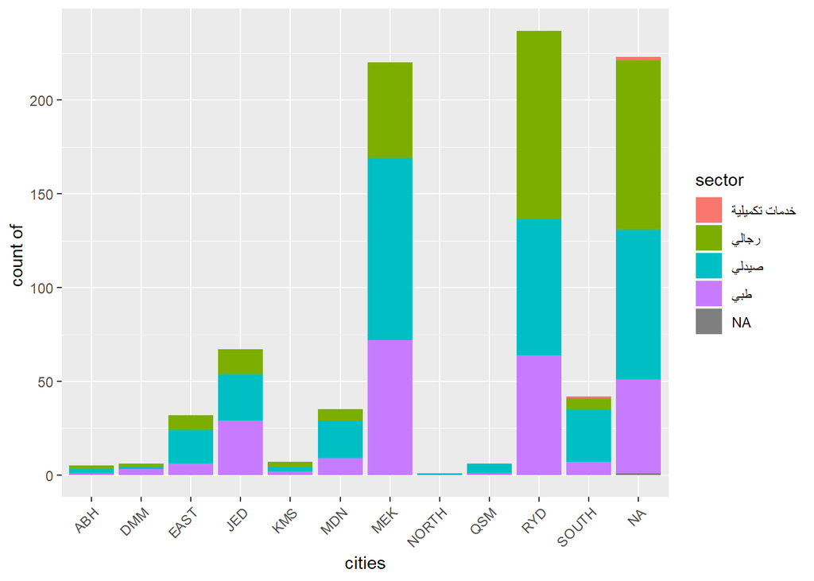